# CSCN8000 – Artificial Intelligence Algorithms and Mathematics

# Midterm Part B: Logistic Regression

##### Dataset file: [Credit Card Fraud Detection on Kaggle](https://www.kaggle.com/datasets/mlg-ulb/creditcardfraud/data)

```python
# All libraries

import pandas as pd
import numpy as np
import seaborn as sns
import matplotlib.pyplot as plt
import statsmodels.api as sm
import scipy.stats as stats
from sklearn.preprocessing import StandardScaler, MinMaxScaler, LabelEncoder
from sklearn.model_selection import train_test_split, cross_val_score
from sklearn.linear_model import LogisticRegression
from sklearn.metrics import accuracy_score, precision_score, recall_score, f1_score, confusion_matrix, roc_curve, auc
from sklearn.neighbors import KNeighborsClassifier
from sklearn.svm import SVC
from sklearn.ensemble import RandomForestClassifier
from sklearn.pipeline import make_pipeline
```

```python
credit = pd.read_csv('.\creditcard.csv')
print(credit.info())
```

```
<class 'pandas.core.frame.DataFrame'>
RangeIndex: 284807 entries, 0 to 284806
Data columns (total 31 columns):
 #   Column  Non-Null Count   Dtype
---  ------  --------------   -----
 0   Time    284807 non-null  float64
 1   V1      284807 non-null  float64
 2   V2      284807 non-null  float64
 3   V3      284807 non-null  float64
 4   V4      284807 non-null  float64
 5   V5      284807 non-null  float64
 6   V6      284807 non-null  float64
 7   V7      284807 non-null  float64
 8   V8      284807 non-null  float64
 9   V9      284807 non-null  float64
```

[output cut: 24 more lines]

```python
credit.head(-1)
```

|  | Time | V1 | V2 | V3 | V4 | V5 | V6 | V7 | V8 | V9 | ... | V21 | V22 | V23 | V24 | V25 | V26 | V27 | V28 | Amount | Class |
| --- | --- | --- | --- | --- | --- | --- | --- | --- | --- | --- | --- | --- | --- | --- | --- | --- | --- | --- | --- | --- | --- |
| 0 | 0.0 | -1.359807 | -0.072781 | 2.536347 | 1.378155 | -0.338321 | 0.462388 | 0.239599 | 0.098698 | 0.363787 | ... | -0.018307 | 0.277838 | -0.110474 | 0.066928 | 0.128539 | -0.189115 | 0.133558 | -0.021053 | 149.62 | 0 |
| 1 | 0.0 | 1.191857 | 0.266151 | 0.166480 | 0.448154 | 0.060018 | -0.082361 | -0.078803 | 0.085102 | -0.255425 | ... | -0.225775 | -0.638672 | 0.101288 | -0.339846 | 0.167170 | 0.125895 | -0.008983 | 0.014724 | 2.69 | 0 |
| 2 | 1.0 | -1.358354 | -1.340163 | 1.773209 | 0.379780 | -0.503198 | 1.800499 | 0.791461 | 0.247676 | -1.514654 | ... | 0.247998 | 0.771679 | 0.909412 | -0.689281 | -0.327642 | -0.139097 | -0.055353 | -0.059752 | 378.66 | 0 |
| 3 | 1.0 | -0.966272 | -0.185226 | 1.792993 | -0.863291 | -0.010309 | 1.247203 | 0.237609 | 0.377436 | -1.387024 | ... | -0.108300 | 0.005274 | -0.190321 | -1.175575 | 0.647376 | -0.221929 | 0.062723 | 0.061458 | 123.50 | 0 |
| 4 | 2.0 | -1.158233 | 0.877737 | 1.548718 | 0.403034 | -0.407193 | 0.095921 | 0.592941 | -0.270533 | 0.817739 | ... | -0.009431 | 0.798278 | -0.137458 | 0.141267 | -0.206010 | 0.502292 | 0.219422 | 0.215153 | 69.99 | 0 |
| ... | ... | ... | ... | ... | ... | ... | ... | ... | ... | ... | ... | ... | ... | ... | ... | ... | ... | ... | ... | ... | ... |
| 284801 | 172785.0 | 0.120316 | 0.931005 | -0.546012 | -0.745097 | 1.130314 | -0.235973 | 0.812722 | 0.115093 | -0.204064 | ... | -0.314205 | -0.808520 | 0.050343 | 0.102800 | -0.435870 | 0.124079 | 0.217940 | 0.068803 | 2.69 | 0 |
| 284802 | 172786.0 | -11.881118 | 10.071785 | -9.834783 | -2.066656 | -5.364473 | -2.606837 | -4.918215 | 7.305334 | 1.914428 | ... | 0.213454 | 0.111864 | 1.014480 | -0.509348 | 1.436807 | 0.250034 | 0.943651 | 0.823731 | 0.77 | 0 |
| 284803 | 172787.0 | -0.732789 | -0.055080 | 2.035030 | -0.738589 | 0.868229 | 1.058415 | 0.024330 | 0.294869 | 0.584800 | ... | 0.214205 | 0.924384 | 0.012463 | -1.016226 | -0.606624 | -0.395255 | 0.068472 | -0.053527 | 24.79 | 0 |
| 284804 | 172788.0 | 1.919565 | -0.301254 | -3.249640 | -0.557828 | 2.630515 | 3.031260 | -0.296827 | 0.708417 | 0.432454 | ... | 0.232045 | 0.578229 | -0.037501 | 0.640134 | 0.265745 | -0.087371 | 0.004455 | -0.026561 | 67.88 | 0 |
| 284805 | 172788.0 | -0.240440 | 0.530483 | 0.702510 | 0.689799 | -0.377961 | 0.623708 | -0.686180 | 0.679145 | 0.392087 | ... | 0.265245 | 0.800049 | -0.163298 | 0.123205 | -0.569159 | 0.546668 | 0.108821 | 0.104533 | 10.00 | 0 |

284806 rows × 31 columns

```python
# Check for missing values in the dataset
missing_values = credit.isnull().sum()
print("Missing Values:\n", missing_values)
```

```
Missing Values:
 Time      0
V1        0
V2        0
V3        0
V4        0
V5        0
V6        0
V7        0
V8        0
V9        0
V10       0
V11       0
V12       0
V13       0
V14       0
V15       0
V16       0
V17       0
V18       0
V19       0
V20       0
V21       0
V22       0
V23       0
V24       0
V25       0
V26       0
V27       0
V28       0
Amount    0
Class     0
dtype: int64
```

# Data Preprocessing Tasks (9 Points):

1. (7 points) Detect and handle outliers for all the numerical features in the dataset using either

the Whiskers Approach, or Z-score approach.

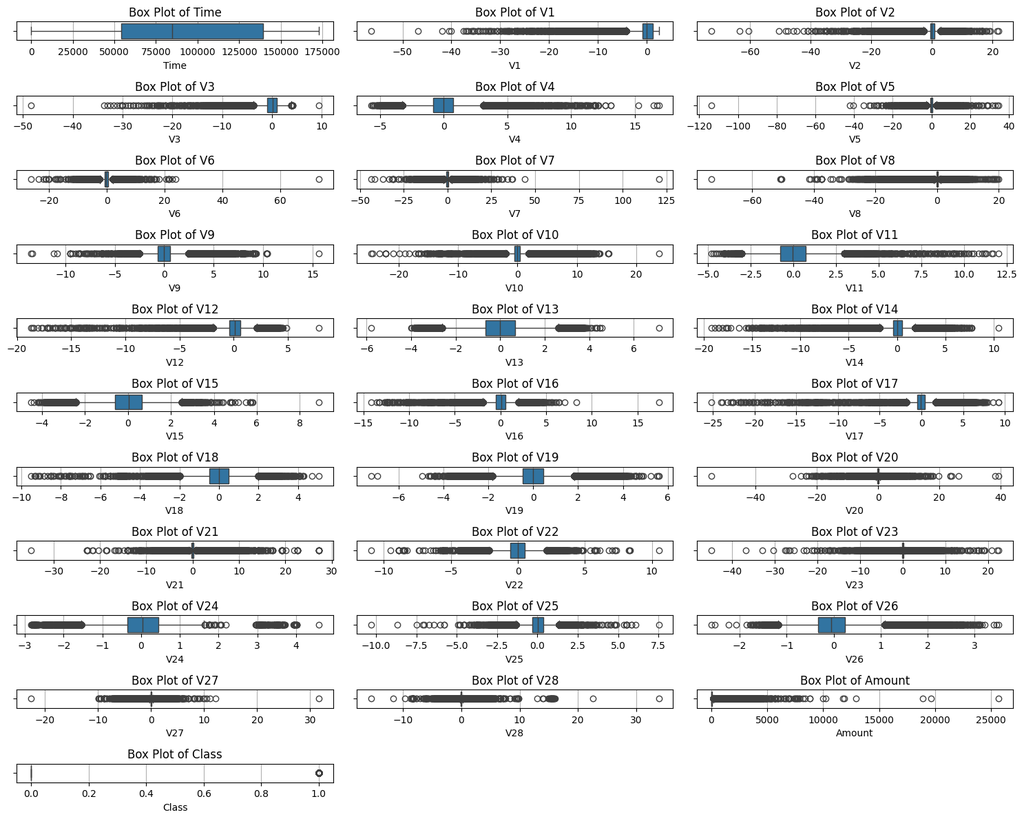

```python
column = credit.columns
# Set the size of the plots
plt.figure(figsize=(15, 12))

# Iterate through each numerical column and plot
for i, col in enumerate(column):
    plt.subplot(len(column) // 3 + 1, 3, i + 1)  # Adjust the number of rows/columns as per your need
    sns.boxplot(x=credit[col])
    plt.title(f'Box Plot of {col}')
    plt.xlabel(col)
    plt.grid(axis='x')

# Adjust layout so plots fit well
plt.tight_layout()
plt.show()
```

```python
# Get numerical columns
numerical_cols = credit.select_dtypes(include=['float64']).columns

features_to_normalize = ['Time'] + [f'V{i}' for i in range(1, 29)] + ['Amount']

# Creating a copy of the original DataFrame for handling outliers
data_cleaned = credit.copy()

# Whiskers Approach to detect and handle outliers
for col in features_to_normalize:
    # Calculate Q1 (25th percentile) and Q3 (75th percentile)
    Q1 = data_cleaned[col].quantile(0.25)
    Q3 = data_cleaned[col].quantile(0.75)
    IQR = Q3 - Q1  # Calculate IQR

    # Define lower and upper bounds
    lower_bound = Q1 - 1.5 * IQR
    upper_bound = Q3 + 1.5 * IQR

        # Replace outliers with the median

    data_cleaned[col] = np.where((data_cleaned[col] < lower_bound) | (data_cleaned[col] > upper_bound),
                                  data_cleaned[col].median(),
                                  data_cleaned[col])

# Display the cleaned DataFrame shape
print(f"Original Data Shape: {credit.shape}")
print(f"Cleaned Data Shape: {data_cleaned.shape}")
```

```
Original Data Shape: (284807, 31)
Cleaned Data Shape: (284807, 31)
```

```python
# Initialize the Min-Max scaler
scaler = MinMaxScaler()

# Select features to normalize
features_to_normalize = ['Time'] + [f'V{i}' for i in range(1, 29)] + ['Amount']

# Create a copy of the original DataFrame for normalization
normalized_data = data_cleaned.copy()

# Normalize the selected features using Min-Max Scaling
normalized_data[features_to_normalize] = scaler.fit_transform(data_cleaned[features_to_normalize])

# Display the first few rows of the normalized data
print(normalized_data.head())
# Display the cleaned DataFrame shape
print(f"Original Data Shape: {credit.shape}")
print(f"Cleaned Data Shape: {normalized_data.shape}")
```

[output not shown]

```python
# # numerical_cols = credit.select_dtypes(include=['float64']).columns


# # Initialize the scaler
# scaler = StandardScaler()

# # Select features to normalize
# # features_to_normalize = ['Time'] + [f'V{i}' for i in range(1, 29)] + ['Amount']
# normalized_data = data_cleaned.copy()

# # Normalize the selected features
# normalized_data[features_to_normalize] = scaler.fit_transform(normalized_data[features_to_normalize])

# # Display the cleaned DataFrame shape
# print(f"Original Data Shape: {credit.shape}")
# print(f"Cleaned Data Shape: {normalized_data.shape}")
```

```python
numerical_cols
```

```
Index(['Time', 'V1', 'V2', 'V3', 'V4', 'V5', 'V6', 'V7', 'V8', 'V9', 'V10',
       'V11', 'V12', 'V13', 'V14', 'V15', 'V16', 'V17', 'V18', 'V19', 'V20',
       'V21', 'V22', 'V23', 'V24', 'V25', 'V26', 'V27', 'V28', 'Amount'],
      dtype='object')
```

```python
normalized_data.describe()
```

|  | Time | V1 | V2 | V3 | V4 | V5 | V6 | V7 | V8 | V9 | ... | V21 | V22 | V23 | V24 | V25 | V26 | V27 | V28 | Amount | Class |
| --- | --- | --- | --- | --- | --- | --- | --- | --- | --- | --- | --- | --- | --- | --- | --- | --- | --- | --- | --- | --- | --- |
| count | 284807.000000 | 284807.000000 | 284807.000000 | 284807.000000 | 284807.000000 | 284807.000000 | 284807.000000 | 284807.000000 | 284807.000000 | 284807.000000 | ... | 284807.000000 | 284807.000000 | 284807.000000 | 284807.000000 | 284807.000000 | 284807.000000 | 284807.000000 | 284807.000000 | 284807.000000 | 284807.000000 |
| mean | 0.548717 | 0.662218 | 0.496184 | 0.501181 | 0.492350 | 0.499069 | 0.484445 | 0.501543 | 0.503413 | 0.495377 | ... | 0.500435 | 0.503031 | 0.497986 | 0.496019 | 0.498668 | 0.509785 | 0.501945 | 0.508658 | 0.181688 | 0.001727 |
| std | 0.274828 | 0.213441 | 0.167988 | 0.170509 | 0.180403 | 0.178731 | 0.161795 | 0.170747 | 0.173652 | 0.186688 | ... | 0.159422 | 0.161651 | 0.173878 | 0.176258 | 0.171364 | 0.194107 | 0.175356 | 0.171400 | 0.216532 | 0.041527 |
| min | 0.000000 | 0.000000 | 0.000000 | 0.000000 | 0.000000 | 0.000000 | 0.000000 | 0.000000 | 0.000000 | 0.000000 | ... | 0.000000 | 0.000000 | 0.000000 | 0.000000 | 0.000000 | 0.000000 | 0.000000 | 0.000000 | 0.000000 | 0.000000 |
| 25% | 0.313681 | 0.511656 | 0.392600 | 0.384402 | 0.379071 | 0.383031 | 0.377811 | 0.384431 | 0.395322 | 0.380137 | ... | 0.386162 | 0.376555 | 0.391939 | 0.384387 | 0.381184 | 0.375996 | 0.411221 | 0.406026 | 0.030352 | 0.000000 |
| 50% | 0.490138 | 0.637869 | 0.493388 | 0.515099 | 0.505096 | 0.497236 | 0.480861 | 0.507108 | 0.482724 | 0.494261 | ... | 0.494913 | 0.503231 | 0.496774 | 0.500366 | 0.499952 | 0.495960 | 0.486472 | 0.497296 | 0.119241 | 0.000000 |
| 75% | 0.806290 | 0.830693 | 0.614648 | 0.625673 | 0.606890 | 0.606622 | 0.571816 | 0.617410 | 0.591542 | 0.611857 | ... | 0.608119 | 0.624301 | 0.602164 | 0.625833 | 0.622155 | 0.611717 | 0.569050 | 0.585372 | 0.240650 | 0.000000 |
| max | 1.000000 | 1.000000 | 1.000000 | 1.000000 | 1.000000 | 1.000000 | 1.000000 | 1.000000 | 1.000000 | 1.000000 | ... | 1.000000 | 1.000000 | 1.000000 | 1.000000 | 1.000000 | 1.000000 | 1.000000 | 1.000000 | 1.000000 | 1.000000 |

8 rows × 31 columns

```python
correlation_matrix = normalized_data.corr()
print(correlation_matrix)
```

```
            Time        V1        V2        V3        V4        V5        V6  \
Time    1.000000  0.154977 -0.018174 -0.478387 -0.174296  0.205830 -0.112719
V1      0.154977  1.000000 -0.399904 -0.397308  0.121812 -0.130815 -0.075188
V2     -0.018174 -0.399904  1.000000  0.067647  0.179976  0.347567 -0.096804
V3     -0.478387 -0.397308  0.067647  1.000000  0.070150 -0.240684  0.277579
V4     -0.174296  0.121812  0.179976  0.070150  1.000000  0.021003  0.134294
V5      0.205830 -0.130815  0.347567 -0.240684  0.021003  1.000000 -0.128756
V6     -0.112719 -0.075188 -0.096804  0.277579  0.134294 -0.128756  1.000000
V7      0.112428 -0.245487  0.452813 -0.094380  0.077995  0.427959 -0.267023
V8     -0.106256 -0.203567  0.001725  0.174096 -0.023717 -0.016854  0.380573
V9      0.008566  0.147437 -0.052022 -0.015829  0.149272 -0.039927  0.043323
V10     0.027572  0.260253 -0.259342 -0.051783 -0.040452 -0.180540  0.080452
V11    -0.246015  0.037806 -0.002294  0.048686  0.002781  0.010714  0.068307
V12     0.023473  0.017459  0.079642 -0.031966  0.182644 -0.009221  0.095387
V13    -0.052377  0.042143  0.023127  0.015082 -0.034586  0.030059 -0.003274
V14    -0.095977 -0.015857  0.114629 -0.139973  0.094813  0.064541 -0.082641
V15    -0.195814  0.042277  0.039307  0.037587  0.055562 -0.030408 -0.095131
V16     0.009485  0.045485  0.045729 -0.037970 -0.069739  0.000531 -0.055277
V17    -0.103930 -0.049566 -0.029624 -0.014249  0.038881 -0.167726  0.030909
V18     0.083129 -0.052711  0.013352 -0.039796  0.019060 -0.007411  0.027316
V19     0.012453 -0.001210  0.016442 -0.005497 -0.023245  0.017521  0.017701
V20    -0.115699 -0.162058  0.055800  0.131815  0.002402  0.094792  0.016478
V21     0.112798 -0.057074 -0.081941 -0.055583  0.019698 -0.040464  0.041979
V22     0.148126 -0.043699 -0.047925 -0.008335 -0.027330 -0.009302  0.063660
V23     0.158034  0.171678 -0.091084 -0.155339  0.008492 -0.108299 -0.052006
V24    -0.009567  0.002362  0.010729 -0.007748 -0.004354 -0.029159 -0.310700
V25    -0.243656  0.078599 -0.084864  0.017337  0.062551  0.004105 -0.049338
V26    -0.028417 -0.005852  0.023396 -0.017700 -0.074235  0.009928 -0.017327
V27    -0.035010 -0.127970  0.146175  0.173098 -0.031796  0.031069  0.079487
V28    -0.122795 -0.220779  0.148132  0.183372  0.012993 -0.001640  0.030234
Amount -0.023705  0.008919 -0.275851  0.039736 -0.033266 -0.149366  0.113966
Class  -0.012323 -0.023371  0.024743 -0.014984  0.024036 -0.008324 -0.026420

              V7        V8        V9  ...       V21       V22       V23  \
Time    0.112428 -0.106256  0.008566  ...  0.112798  0.148126  0.158034
V1     -0.245487 -0.203567  0.147437  ... -0.057074 -0.043699  0.171678
V2      0.452813  0.001725 -0.052022  ... -0.081941 -0.047925 -0.091084
V3     -0.094380  0.174096 -0.015829  ... -0.055583 -0.008335 -0.155339
V4      0.077995 -0.023717  0.149272  ...  0.019698 -0.027330  0.008492
V5      0.427959 -0.016854 -0.039927  ... -0.040464 -0.009302 -0.108299
```

[output cut: 45 more lines]

```
V18    -0.050817 -0.008614  0.003000  0.015258  0.023495  0.042706 -0.006112
V19    -0.064929  0.014078 -0.043261  0.006133 -0.013054 -0.003579  0.011086
V20     0.039215  0.037491  0.041048  0.086854  0.170373  0.094334  0.014676
V21     0.034557  0.033571 -0.015306 -0.037295  0.077190  0.079320  0.019007
V22     0.013114  0.011116 -0.014643  0.053323 -0.010212  0.061245  0.000927
V23     0.111513 -0.431558 -0.033243  0.033464 -0.072037  0.010138 -0.006155
V24     1.000000 -0.003536  0.010851 -0.033935  0.041031 -0.014675 -0.008986
V25    -0.003536  1.000000 -0.029458 -0.123707 -0.096046  0.029124  0.004916
V26     0.010851 -0.029458  1.000000 -0.158189 -0.018635 -0.042385  0.004061
V27    -0.033935 -0.123707 -0.158189  1.000000  0.366035 -0.054419  0.001352
V28     0.041031 -0.096046 -0.018635  0.366035  1.000000 -0.037645  0.008388
Amount -0.014675  0.029124 -0.042385 -0.054419 -0.037645  1.000000 -0.005213
Class  -0.008986  0.004916  0.004061  0.001352  0.008388 -0.005213  1.000000

[31 rows x 31 columns]
```

The Whiskers Approach (IQR Method) is typically the preferred option for the Credit Card Fraud Detection dataset because of the following characteristics for credit dataset:

1. Robust to Skewed Distributions: It performs well with the skewed distribution commonly seen in this binary classification scenario, where fraudulent activities are infrequent.
2. Handling Imbalance: By closely considering the IQR, it balances out the representation of both legitimate and fraudulent transactions, making it less likely that fraudulent transactions are misclassified as outliers.
3. Data Integrity: It avoids the excessive influence of outliers on mean and standard deviation calculations, which is critical in a dataset where misclassifying legitimate extreme transactions could skew analyses and models.
2. (2 points) After some analysis, if you conclude it’s needed, normalize numerical features using

appropriate method based on feature characteristics.

Using Min-max normalization since it is less sensitive to outliers and suitable for the scale

```python
column
```

```
Index(['Time', 'V1', 'V2', 'V3', 'V4', 'V5', 'V6', 'V7', 'V8', 'V9', 'V10',
       'V11', 'V12', 'V13', 'V14', 'V15', 'V16', 'V17', 'V18', 'V19', 'V20',
       'V21', 'V22', 'V23', 'V24', 'V25', 'V26', 'V27', 'V28', 'Amount',
       'Class'],
      dtype='object')
```

```python
normalized_data['Class'].unique()
```

```
array([0, 1])
```

```python
# from sklearn.preprocessing import StandardScaler

# scaler = StandardScaler()
# credit_cleaned[numerical_cols] = scaler.fit_transform(credit_cleaned[numerical_cols])
```

```python
# # Initialize the scaler
# scaler = StandardScaler()

# # Select features to normalize
# features_to_normalize = ['Time'] + [f'V{i}' for i in range(1, 29)] + ['Amount']
# normalized_data = credit_cleaned.copy()

# # Normalize the selected features
# normalized_data[features_to_normalize] = scaler.fit_transform(credit_cleaned[features_to_normalize])
```

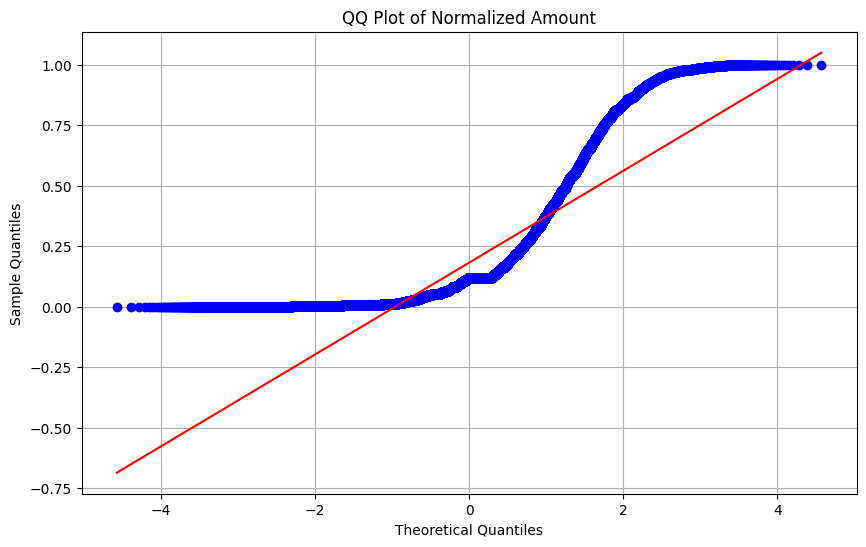

```python
normalized_amount = normalized_data['Amount']

# Create the QQ Plot
plt.figure(figsize=(10, 6))
stats.probplot(normalized_amount, dist="norm", plot=plt)
plt.title('QQ Plot of Normalized Amount')
plt.xlabel('Theoretical Quantiles')
plt.ylabel('Sample Quantiles')
plt.grid()
plt.show()
```

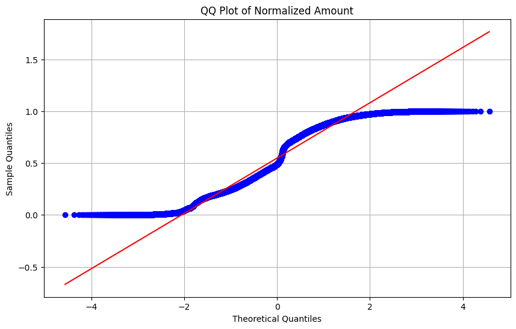

```python
normalized_amount = normalized_data['Time']

# Create the QQ Plot
plt.figure(figsize=(10, 6))
stats.probplot(normalized_amount, dist="norm", plot=plt)
plt.title('QQ Plot of Normalized Amount')
plt.xlabel('Theoretical Quantiles')
plt.ylabel('Sample Quantiles')
plt.grid()
plt.show()
```

# Descriptive Analytics Tasks (10 Points):

1. (2 points) Analyze the distribution of fraud vs non-fraud transactions and comment on it.

```python
# Count the number of fraud and non-fraud transactions
class_distribution = normalized_data['Class'].value_counts()
print(class_distribution)
```

```
Class
0    284315
1       492
Name: count, dtype: int64
```

The dataset reveals a stark class imbalance:

- Non-Fraud Transactions (Class 0): 284,315
- Fraud Transactions (Class 1): 492

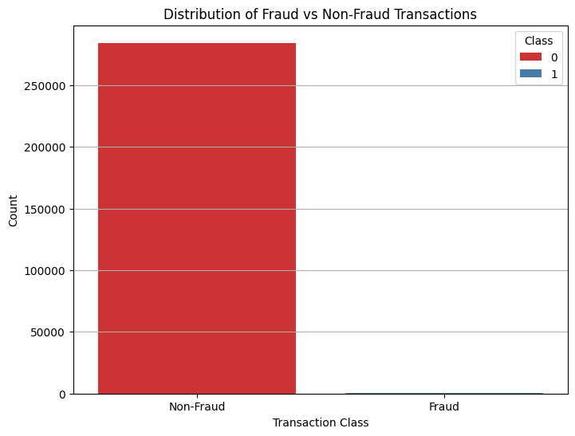

```python
# Visualization
plt.figure(figsize=(8, 6))
sns.countplot(data=normalized_data, x='Class',hue='Class', palette='Set1')
plt.title('Distribution of Fraud vs Non-Fraud Transactions')
plt.xlabel('Transaction Class')
plt.ylabel('Count')
plt.xticks(ticks=[0, 1], labels=['Non-Fraud', 'Fraud'])
plt.grid(axis='y')
plt.show()
```

The count plot visually reinforces the findings of the class distribution.

- The chart displays a high bar representing non-fraudulent transactions, towering over the small bar depicting fraudulent transactions.
- The evident visual distinction emphasizes the disparity and hints that predictive models may face challenges in detecting fraudulent transactions if they are not tailored for imbalanced datasets.

```python
# Descriptive statistics for Amount
fraud_amount = normalized_data[normalized_data['Class'] == 1]['Amount']
non_fraud_amount = normalized_data[normalized_data['Class'] == 0]['Amount']
```

```python
print(f"Mean Amount for Fraud Transactions: {fraud_amount.mean()}")
print(f"Mean Amount for Non-Fraud Transactions: {non_fraud_amount.mean()}")
print(f"Median Amount for Fraud Transactions: {fraud_amount.median()}")
print(f"Median Amount for Non-Fraud Transactions: {non_fraud_amount.median()}")
```

```
Mean Amount for Fraud Transactions: 0.1545526252010488
Mean Amount for Non-Fraud Transactions: 0.18173500030763812
Median Amount for Fraud Transactions: 0.05013550135501355
Median Amount for Non-Fraud Transactions: 0.11924119241192412
```

- The average for fraudulent transactions is lower than for non-fraudulent transactions, which comes as a surprise. This may indicate that deceptive transactions frequently consist of lower amounts, even though the data could be influenced by outliers or a low median.
- The median value of fraudulent transactions is considerably less than non-fraudulent ones, highlighting the possible range of fraudulent activities.
2. (4 points) Analyze the correlation between fraud/non-fraud transactions and all the other numerical features.

   a. Comment on which features have the highest correlation with the target variable.

```python
# Calculate correlation matrix
correlation_matrix_class = normalized_data.corr()

# Extract correlation with 'Class'
fraud_correlations = correlation_matrix_class['Class'].sort_values(ascending=False)
print(fraud_correlations)
```

```
Class     1.000000
V2        0.024743
V4        0.024036
V11       0.022019
V21       0.019007
V20       0.014676
V19       0.011086
V28       0.008388
V8        0.006375
V25       0.004916
V26       0.004061
V17       0.001454
V27       0.001352
V22       0.000927
V15      -0.001934
V16      -0.002305
V14      -0.002560
V13      -0.003779
V12      -0.004090
V10      -0.005007
Amount   -0.005213
V18      -0.006112
V23      -0.006155
V5       -0.008324
V24      -0.008986
V7       -0.009191
Time     -0.012323
V3       -0.014984
V9       -0.020085
V1       -0.023371
V6       -0.026420
Name: Class, dtype: float64
```

1. Positive correlation: `V11`, `V4`, and `V2` display slight positive connections, indicating that greater amounts may be linked to deceitful transactions. Comprehending the background of these characteristics may help shape your approach to modeling.
2. Negative correlation: `V1` and `V6` exhibit the strongest negative correlations with fraud. This indicates that they could be used as signs of valid transactions. Further exploration of these characteristics could reveal the reason they are associated with honest conduct.
3. `Time` and `Amount`: `Time` and `Amount` display negative low correlations, suggesting they might not be reliable indicators of fraudulent behavior. Nevertheless, they could retain significance in certain scenarios or when paired with other characteristics.
3. (4 points) From the previous step, choose the 10 features with highest correlation with the target variable, and plot their distributions against the fraud/non-fraud transactions.

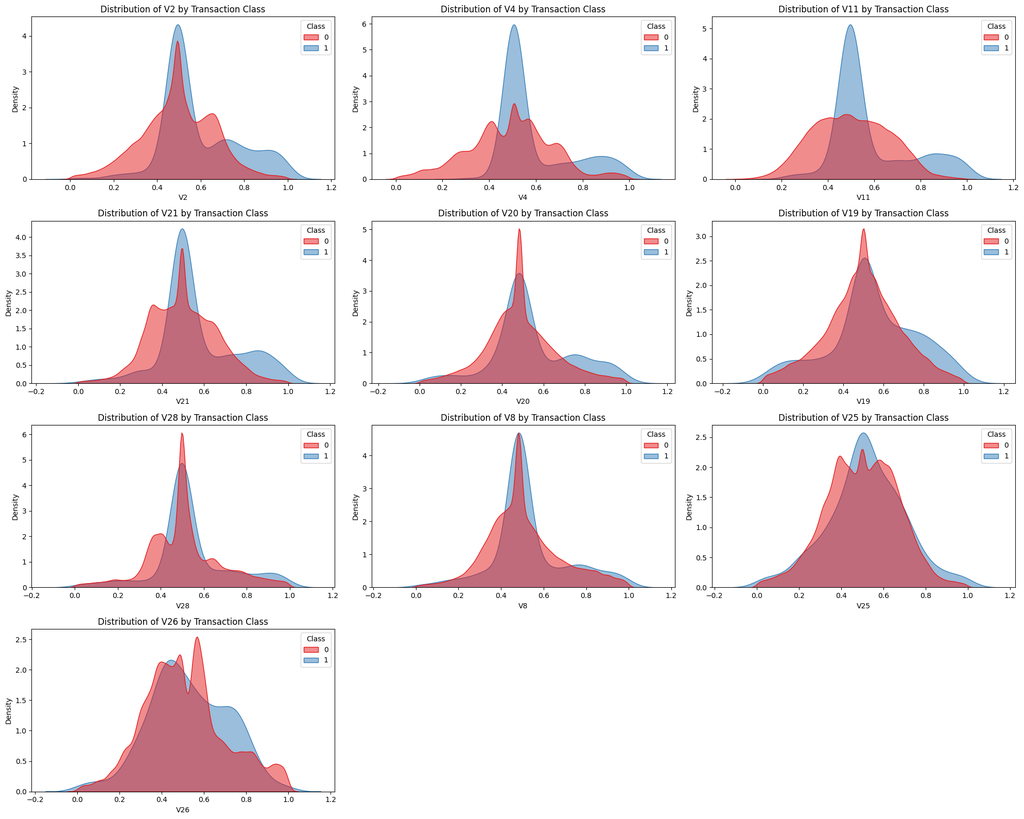

```python
top_10_features = fraud_correlations.index[1:11]

plt.figure(figsize=(20, 16))

for i, feature in enumerate(top_10_features):
    plt.subplot(4, 3, i + 1)  # 4 rows and 3 columns
    sns.kdeplot(data=normalized_data, x=feature, hue='Class', common_norm=False, fill=True,
                 palette='Set1', alpha=0.5)
    plt.title(f'Distribution of {feature} by Transaction Class')
    plt.xlabel(feature)
    plt.ylabel('Density')

plt.tight_layout()
plt.show()
```

- Most of the features exhibit overlapping distributions between fraudulent and non-fraudulent transactions, making it challenging to distinguish between the two classes based solely on these features.
- Certain features reveal slight shifts in density towards one class, suggesting potential areas for further investigation. For instance, if the density of fraudulent transactions is consistently higher at specific feature values, it may warrant further exploration.

# ML Model Training and Testing Tasks (27 Points):

1. (2 point) Split the cleaned data into training and testing sets (e.g., 80% training, 20% testing).

```python
# Separate features and target variable
X = normalized_data.drop('Class', axis=1)  # Features
y = normalized_data['Class']  # Target

# Split the data into training and testing sets (80% training, 20% testing)
X_train, X_test, y_train, y_test = train_test_split(X, y, test_size=0.2, random_state=42, stratify=y)

# Display the shapes of the resulting datasets
print(f"Training set shape: {X_train.shape}, Testing set shape: {X_test.shape}")
print(f"Training labels shape: {y_train.shape}, Testing labels shape: {y_test.shape}")
```

```
Training set shape: (227845, 30), Testing set shape: (56962, 30)
Training labels shape: (227845,), Testing labels shape: (56962,)
```

2. (3 points) Use 5-fold cross-validation to train and validate the performance of all the models in this section.

```python
models = {
    'Logistic Regression': LogisticRegression(max_iter=1000),
    'K-Nearest Neighbors': KNeighborsClassifier(),
    'Support Vector Machine': SVC(kernel='linear',C=1.0,probability=True)
    }
# models = LogisticRegression(max_iter=1000)

# Cross-validation and model evaluation
for model_name, model in models.items():
    # Create a pipeline with standard scaling and the model
    pipeline = make_pipeline(StandardScaler(), model)

    # Perform 5-fold cross-validation
    cv_scores = cross_val_score(pipeline, X_train, y_train, cv=5, scoring='f1')  # Use F1 score for imbalance

    print(f"{model_name}: Mean F1 Score = {cv_scores.mean():.4f} (+/-) {cv_scores.std():.4f}")
```

```
Logistic Regression: Mean F1 Score = 0.1648 (+/-) 0.0407
K-Nearest Neighbors: Mean F1 Score = 0.4406 (+/-) 0.0349
Support Vector Machine: Mean F1 Score = 0.0000 (+/-) 0.0000
```

3. (3 points) Train a logistic regression model as a baseline model.

```python
# Train the model
models['Logistic Regression'].fit(X_train, y_train)

# Predictions on the test set
y_pred_baseline = models['Logistic Regression'].predict(X_test)
```

```python
# Train the model
models['K-Nearest Neighbors'].fit(X_train, y_train)

# Predictions on the test set
y_pred_KNN = models['K-Nearest Neighbors'].predict(X_test)
```

```python
# Train the model
models['Support Vector Machine'].fit(X_train, y_train)

# Predictions on the test set
y_pred = models['Support Vector Machine'].predict(X_test)
```

4. (2 points) Print the learned coefficients (weights) of the model.

   a. Comment on which feature the model gave higher weight to in the weight vector.

```python
# Print the learned coefficients
coefficients = models['Logistic Regression'].coef_[0]
feature_names = X.columns

# Create a DataFrame for better visualization
coef_df = pd.DataFrame({'Feature': feature_names, 'Coefficient': coefficients})

# Sort by absolute value of coefficients
coef_df['AbsCoefficient'] = coef_df['Coefficient'].abs()
coef_df = coef_df.sort_values(by='AbsCoefficient', ascending=False)

# Print the coefficients
print("Learned Coefficients (Weights):")
print(coef_df[['Feature', 'Coefficient']])

# Display the feature with the highest absolute coefficient
highest_weight_feature = coef_df.iloc[0]
print(f"\nFeature with the highest weight: {highest_weight_feature['Feature']} "
      f"with a coefficient of {highest_weight_feature['Coefficient']:.4f}")
```

```
Learned Coefficients (Weights):
   Feature  Coefficient
6       V6    -4.601846
4       V4     3.829681
11     V11     3.400906
3       V3    -2.837036
2       V2     2.800167
7       V7    -2.499216
21     V21     2.384050
24     V24    -2.287770
14     V14    -2.222361
17     V17    -2.210613
16     V16    -2.064250
9       V9    -2.062917
5       V5    -1.946757
```

[output cut: 19 more lines]

5. (4 Points) Evaluate the model's performance on the test set using the following metrics:

   a. Accuracy

   b. Precision

   c. Recall

   d. F1-Score

```python
# Evaluate the model
accuracy = accuracy_score(y_test, y_pred_baseline)
precision = precision_score(y_test, y_pred_baseline)
recall = recall_score(y_test, y_pred_baseline)
f1 = f1_score(y_test, y_pred_baseline)
confusion = confusion_matrix(y_test, y_pred_baseline)

# Output the evaluation metrics
print("Logistic Regression Model Performance:")
print(f"Accuracy: {accuracy:.4f}")
print(f"Precision: {precision:.4f}")
print(f"Recall: {recall:.4f}")
print(f"F1 Score: {f1:.4f}")
print(f"Confusion Matrix:\n{confusion}")
```

```
Logistic Regression Model Performance:
Accuracy: 0.9984
Precision: 1.0000
Recall: 0.0816
F1 Score: 0.1509
Confusion Matrix:
[[56864     0]
 [   90     8]]
```

6. (6 Points) Evaluate the performance of the logistic regression model using Log-Loss (Cross-Entropy).

   a. Calculate the log-loss for the logistic regression model on the test set. Do this calculation manually using numpy only (no explicit library functions).

   b. Compare the log-loss value with the other evaluation metrics (accuracy, precision, recall, F1-Score).

   c. Comment on what log-loss reveals about the model’s performance in comparison to other metrics and how it handles misclassified probabilities.

```python
# Get predicted probabilities for class 1
y_probs = models['Logistic Regression'].predict_proba(X_test)[:, 1]

# True labels for test set
y_true = y_test.values

# Calculate Log-Loss manually
N = len(y_true)
log_loss = -np.sum(y_true * np.log(y_probs) + (1 - y_true) * np.log(1 - y_probs)) / N

print(f"Log-Loss: {log_loss:.4f}")
```

```
Log-Loss: 0.0095
```

Log-loss is influenced by the level of certainty in predictions. A small log-loss value (0.0095) indicates that the model is able to predict fraud instances with a high level of confidence, leading to minimal consequences for incorrect classifications. It indicates that the model's probabilities are accurate for identifying fraud, but there is a high rate of misclassification due to low recall.

- Comparison with other measurements:
  - Despite a low log-loss, the ability to detect fraudulent cases may still be lacking, as indicated by the recall and F1 score. Therefore, it is important to not depend only on log-loss, particularly in situations with imbalances, where the expenses of false negatives can be substantial.
- Dealing with incorrectly classified probabilities:
  - Log-loss penalizes wrong predictions by considering the certainty of the prediction instead of just focusing on the number of correct classifications. If the model predicts numerous transactions as non-fraud when they are actually fraud, the log-loss will rise significantly, prompting enhancements in both accuracy and recall, not just precision.
7. (4 Points) Plot the ROC Curve and print the AUC of the model on the test set. Comment on the quality of the model performance as seen in the ROC curve.

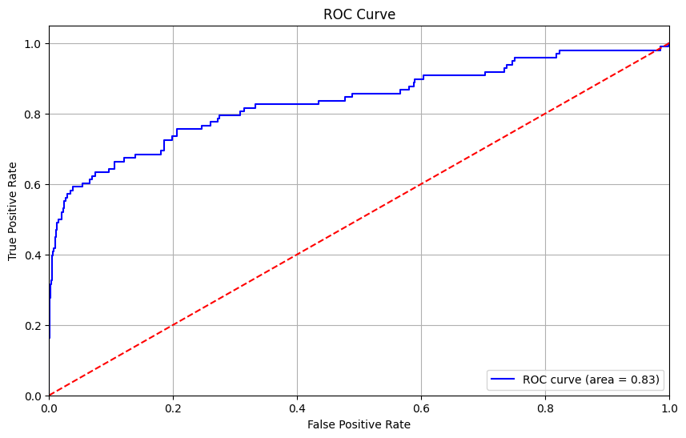

```
AUC: 0.8346
```

```python
# Calculate ROC curve
fpr, tpr, _ = roc_curve(y_test, y_probs)
roc_auc = auc(fpr, tpr)

# Plot the ROC curve
plt.figure(figsize=(10, 6))
plt.plot(fpr, tpr, color='blue', label='ROC curve (area = %0.2f)' % roc_auc)
plt.plot([0, 1], [0, 1], color='red', linestyle='--')  # Diagonal line
plt.xlim([0.0, 1.0])
plt.ylim([0.0, 1.05])
plt.xlabel('False Positive Rate')
plt.ylabel('True Positive Rate')
plt.title('ROC Curve')
plt.legend(loc='lower right')
plt.grid(True)
plt.show()

# Print AUC value
print(f"AUC: {roc_auc:.4f}")
```

- The True Positive Rate (TPR) is the percentage of real positives that the model correctly identifies, displayed on the y-axis.
- The False Positive Rate (FPR) on the x-axis shows the percentage of real negatives that are mistakenly classified as positives.

Insights from ROC:

- The steep initial rise of the curve is advantageous because it indicates that the model can achieve a high true positive rate while keeping the false positive rate relatively low.
- The curve plateaus, showing that performance starts decreasing as the false positive rate goes up.

Insights from AUC:

- An AUC value of 0.83 indicates a high degree of differentiation between the fraudulent and non-fraudulent classes. It suggests that the model can accurately order the likelihood of fraud compared to non-fraud transactions in a large majority of cases.

The diagonal red line in the plot represents the performance of a random classifier, which has an AUC of 0.5. The logistic regression model's AUC of 0.83 is well above this, indicating that it provides a strong classification capability.

Overall Performance:

- Although the model has high accuracy and precision, it has a low recall of 8.16%, indicating it has difficulty detecting real fraud instances. This difference indicates that although the model accurately predicts a small number of real fraud cases, it misses a large number of them. The ROC curve and AUC can provide a more detailed perspective compared to solely focusing on accuracy or precision.
- The ROC curve's behavior indicates that improving recall will likely increase false positives. This is particularly important in fraud detection; while high precision is valuable, being able to capture as many fraudulent transactions as possible (high recall) is critical.
8. (3 Points) Try the KNN and SVM classification compare their performance to the logistic regression baseline.

```python
# KNN Classifier
knn_model = KNeighborsClassifier(n_neighbors=5)  # You can tune this parameter
knn_model.fit(X_train, y_train)
y_knn_pred = knn_model.predict(X_test)

# Evaluate KNN Model
knn_accuracy = accuracy_score(y_test, y_knn_pred)
knn_precision = precision_score(y_test, y_knn_pred)
knn_recall = recall_score(y_test, y_knn_pred)
knn_f1 = f1_score(y_test, y_knn_pred)

# Calculate ROC and AUC for KNN
y_knn_probs = knn_model.predict_proba(X_test)[:, 1]
fpr_knn, tpr_knn, _ = roc_curve(y_test, y_knn_probs)
knn_auc = auc(fpr_knn, tpr_knn)

# Print the results
print("KNN Model Performance:")
print(f"Accuracy: {knn_accuracy:.4f}, Precision: {knn_precision:.4f}, Recall: {knn_recall:.4f}, F1 Score: {knn_f1:.4f}, AUC: {knn_auc:.4f}")
```

```
KNN Model Performance:
Accuracy: 0.9987, Precision: 0.8333, Recall: 0.3061, F1 Score: 0.4478, AUC: 0.8157
```

```python
# SVM Classifier
svm_model = SVC(kernel='linear',C=1.0, probability=True)  # Enable probability estimates
svm_model.fit(X_train, y_train)
y_svm_pred = svm_model.predict(X_test)

# Evaluate SVM Model
svm_accuracy = accuracy_score(y_test, y_svm_pred)
svm_precision = precision_score(y_test, y_svm_pred)
svm_recall = recall_score(y_test, y_svm_pred)
svm_f1 = f1_score(y_test, y_svm_pred)

# Calculate ROC and AUC for SVM
y_svm_probs = svm_model.predict_proba(X_test)[:, 1]
fpr_svm, tpr_svm, _ = roc_curve(y_test, y_svm_probs)
svm_auc = auc(fpr_svm, tpr_svm)

print("\nSVM Model Performance:")
print(f"Accuracy: {svm_accuracy:.4f}, Precision: {svm_precision:.4f}, Recall: {svm_recall:.4f}, F1 Score: {svm_f1:.4f}, AUC: {svm_auc:.4f}")
```

```
SVM Model Performance:
Accuracy: 0.9983, Precision: 0.0000, Recall: 0.0000, F1 Score: 0.0000, AUC: 0.7048
```

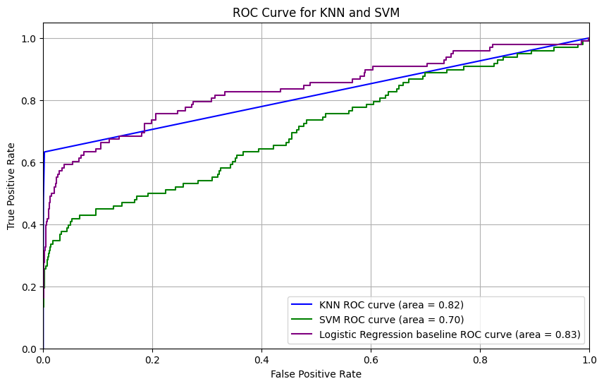

```python
# Plot ROC Curves
plt.figure(figsize=(10, 6))
plt.plot(fpr_knn, tpr_knn, color='blue', label='KNN ROC curve (area = {:.2f})'.format(knn_auc))
plt.plot(fpr_svm, tpr_svm, color='green', label='SVM ROC curve (area = {:.2f})'.format(svm_auc))
plt.plot(fpr, tpr, color='purple', label='Logistic Regression baseline ROC curve (area = %0.2f)' % roc_auc)
plt.xlim([0.0, 1.0])
plt.ylim([0.0, 1.05])
plt.xlabel('False Positive Rate')
plt.ylabel('True Positive Rate')
plt.title('ROC Curve for KNN and SVM')
plt.legend(loc='lower right')
plt.grid(True)
plt.show()
```

| Metric | Logistic Regression | KNN | SVM |
| --- | --- | --- | --- |
| Accuracy | 0.9984 | 0.9987 | 0.9983 |
| Precision | 1.0000 | 0.8333 | 0.0000 |
| Recall | 0.0816 | 0.3061 | 0.0000 |
| F1-score | 0.1509 | 0.4478 | 0.0000 |
| AUC | 0.8300 | 0.8157 | 0.7048 |